# NBA-All-Star Project

#### Feature selection

Used Boruta algorithm feature selection to select the important features. I used Boruta Algorithm to extract all the important features from the dataset. Then I used these features to create our logistic model and classification trees. As the plot shows below, the red and green color shows whether the variable is important or not, yellow indicates tentative features which can not decide.

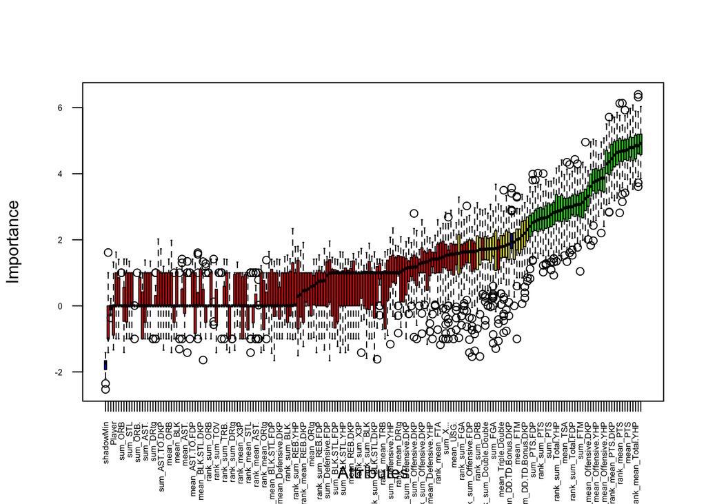

```r
## use boruta package to find relevant features

## set results are repeatable
set.seed(100)
library(Boruta)
boruta <- Boruta(select ~., data = d2015west, doTrace = 2)
# green and red color show whether important or not, yellow indicates tentative
# features can't decided
plot(boruta, las = 2, cex.axis = 0.5)
```

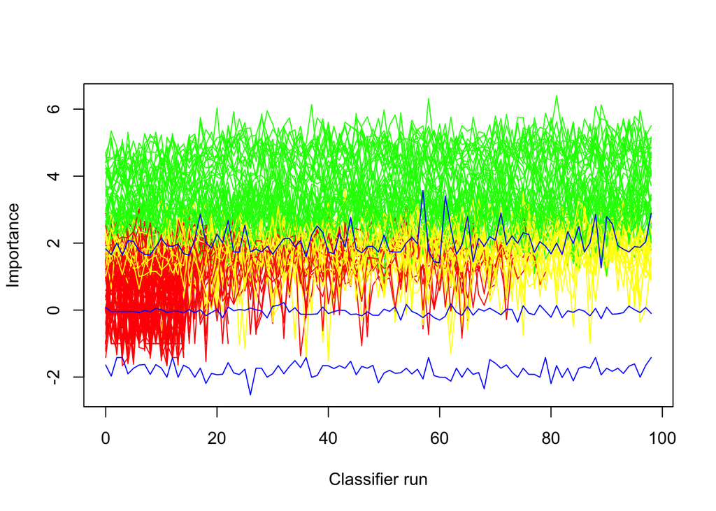

```r
plotImpHistory(boruta)
```

```r
# attStats(boruta)
selectedAttributes <- names(boruta$finalDecision[boruta$finalDecision == "Confirmed"])

# Tentative fix
ten_fix <- TentativeRoughFix(boruta)
ten_fix
```

```
## Boruta performed 99 iterations in 9.21788 secs.
## Tentatives roughfixed over the last 99 iterations.
##  49 attributes confirmed important: mean_FGA, mean_FGM,
## mean_Offensive.DKP, mean_Offensive.FDP, mean_Offensive.YHP and 44 more;
##  152 attributes confirmed unimportant: mean_AST, mean_AST.,
## mean_AST.TO.DKP, mean_AST.TO.FDP, mean_AST.TO.YHP and 147 more;
```